# WEEK2: Resampling Methods

# Objective

This homework sheet will help reviewing the basic concepts associated with model selection and regularization. Please review the lectures, suggested readings, and additional resources *before* getting started on the HW.

**Some questions in this assignment will require you to conduct independent research beyond the material covered in the recorded content.**

**Questions**

This homework is divided into two main parts. First, a conceptual component will review the basic concepts related to resampling. The second part of the homework is mostly intended to be a brief introduction to regularization methods and resampling in python . Several of these questions are modified from James et al. (2021).

Marks Distribution

| Question | Marks |
| --- | --- |
| Q1a | 1 |
| Q1b | 0.50 |
| Q1c | 1 |
| Q1d | 0.50 |
| Q1e | 0.50 |
| Q1f | 0.50 |
| Q2a | 1 |
| Q2b | 1 |
| Q2c | 1 |
| Q2d | 1 |
| Q3a | 1 |
| Q3b | 1 |
| Q4 | 1 |
| Q5a | 1 |
| Q5b | 1 |
| Q5c | 1 |
| Q5d | 1 |

# Conceptual

## Q1. We will derive the probability that a given observation is part of a bootstrap sample. Suppose that we obtain a bootstrap sample from a set of `n` observations. **Please note that samples are obtained with replacement**.

### a) What is the probability that the first bootstrap observation is not the $jth$ observation from the original sample? Justify your answer.

Provide your answer in this Markdown cell

1. We have a total of n observations and we need to pick the first bootstrap observation that is not the $j^{th}$ observation from the original sample.
2. So, the number of observations in the original sample excluding the $j^{th}$ observation is n-1.
3. Probability that the first bootstrap observation is not the $j^{th}$ observation from the original sample is the number of observations in the original sample excluding the $j^{th}$ observation divided by the total number of observations in the original sample.
4. Therefore, the probability is $${n-1}\over {n}$$

### b) What is the probability that the second bootstrap observation is not the $jth$ observation from the original sample?

Provide your answer in this Markdown cell

1. Probability that the second bootstrap observation is not the $j^{th}$ observation from the original sample is the number of observations in the original sample excluding the $j^{th}$ observation divided by the total number of observations in the original sample.
2. The number of observations in the original sample excluding the $j^{th}$ observation is n-1.
3. Therefore, the probability is $${n-1}\over{n}$$

### c) Argue that the probability that the $jth$ observation is not in the bootstrap sample is $(1 − 1/n)^n$.

Provide your answer in this Markdown cell

1. Probability that the $j^{th}$ observation is not in the bootstrap sample is the product of probabilties that the each bootstrap observation is not the $j^{th}$ observation from the original sample.
2. Probability that any $k^{th}$ observation in the bootstrap sample is not the $j^{th}$ observation is the number of observations in the original sample excluding the $j^{th}$ observation divided by the total number of observations in the original sample. This probability is $${n-1}\over{n}$$
3. Now the above probability is multiplied n-times as these are independent events and size of bootstrap sample is same as the size of original sample(n).
4. The probability is $${\prod_{i=1}^{n}} {n-1\over n} = (1 − 1/n)^n$$

### d) When `n = 5`, what is the probability that the $jth$ observation is in the bootstrap sample?

Provide your answer in this Markdown cell

1. The probability that the $j^{th}$ observation is in the bootstrap sample is equal to one minus the probability that the $j^{th}$ observation is not in the bootstrap sample.
2. The probability is given by $1-(1-1/n)^{n}$ where n=5 in this case.
3. Therefore, $$1-(1-1/5)^{5} = 0.67232 $$

### e) When `n = 100`, what is the probability that the $jth$ observation is in the bootstrap sample?

Provide your answer in this Markdown cell

1. The probability that the $j^{th}$ observation is in the bootstrap sample is equal to one minus the probability that the $j^{th}$ observation is not in the bootstrap sample.
2. The probability is given by $1-(1-1/n)^{n}$ where n=100 in this case.
3. Therefore, $$1-(1-1/100)^{100} = 0.63397 $$

### f) When `n = 1000`, what is the probability that the $jth$ observation is in the bootstrap sample?

Provide your answer in this Markdown cell

Provide your answer in this Markdown cell

1. The probability that the $j^{th}$ observation is in the bootstrap sample is equal to one minus the probability that the $j^{th}$ observation is not in the bootstrap sample.
2. The probability is given by $1-(1-1/n)^{n}$ where n=1000 in this case.
3. Therefore, $$1-(1-1/1000)^{1000} = 0.63231 $$

## Q2)

The following questions are relative to k-fold cross-validation.

### a) Explain how k-fold cross-validation is implemented.

Provide your answer in this Markdown cell

1. In k-fold cross-validation, the training dataset is split into k-partitions that do not overlap with each other.
2. In each iteration, 1 partition is used as a validation set and the remaining k-1 partitions are used to fit the model.
3. In each iteration MSE is calculated on that 1 partition or fold used as a validation set. Let $MSE_{i}$ represent the mean squared error in the $i^{th}$ iteration where $i^{th}$ partition is used as a validation set.
4. The average of $MSE_{i}$ over all the k-folds or k-partitions gives the estimate of the test error. It is given by $${1 \over k}\sum_{i=1}^{k}MSE_{i}$$

### b) How would you choose the analyzed k? Does that matter?

Provide your answer in this Markdown cell

1. The value of k depends on factors such as size of the dataset and bias-variance trade-off.
2. If the size of the dataset is small then a large k-value results in an accurate estimate of the test error whereas if the size of the dataset is large then a small k-value results in a good estimate of the test error.
3. On the other hand, a small k-value results in a model with high bias and low variance whereas a large k-value results in a model with low bias and high variance.
4. As k increases the variance increases because of the increase in the overlap of training sets which results in nearly identical observations. On the other hand, a small k value results in a small overlap in training sets.
5. We need to choose the k value keeping in view of the above implications and in general we choose a k value that results in neither high bias nor high variance.
6. Practically, k=5 or k=10 is considered as it results in test error estimate that has neither high bias nor high variance.

### c) What are the advantages and disadvantages of k-fold cross-validation relative to: *The validation set* approach?

Provide your answer in this Markdown cell

1. The validation set approach tends to overestimate the test error as it uses only 50% of the observations to train the model and the remaining 50% are used as a validation set. On the contrary the k-fold cross validation approach uses $(k-1)*n/k$ observations to train the model and $n/k$ observations as validation set(k=5 or 10 in general). In k-fold cross validation, more observations are used to train the model compared to the validation set approach. Hence, k-fold cross validation approach results in a better estimate of test set error compared to the validation set approach.
2. In validation set approach, the model is trained on fewer observations which results in high variability of the test set error estimate. But in k-fold cross-validation, the model is trained on more number of observations which results in decrease in the variability of the test set error estimate.
3. On the other hand, the disadvantage of k-fold cross validation is that it is computationally more expensive than the validation set approach. In validation set approach the model is fit only once whereas in k-fold cross validation the model is fit k-times which increases the number of computations.

### d) What are the advantages and disadvantages of k-fold cross-validation relative to: *LOOCV*?

Provide your answer in this Markdown cell

1. LOOCV is a special case of k-fold cross-validation in which k is equal to the size of the dataset(k=n). In each iteration, n-1 observations are used to fit the model and the remaining one observation is used for prediction. Here the test set error estimate is given by $${1 \over n}\sum_{i=1}^{n}MSE_{i}$$
2. Each training set in LOOCV approach has n-1 observations, which is nearly all the observations of the dataset. So, it gives nearly unbiased estimates of the test set error. But in k-fold cross-validation(k<n), only $(k-1)*n/k$ observations(fewer than in the LOOCV approach) are used to fit the model. This results in a relatively more biased estimate of test set error compared to the LOOCV approach. Hence, the LOOCV has far less bias compared to k-fold cross validation approach(k<n).
3. The disadvantage is that LOOCV has more variance than k-fold cross validation(k<n) because the model is trained on nearly same data each time and the average prediction error is calculated. Moreover, these prediction errors are highly correlated because the fitted models do not differ in the training data significantly. In k-fold cross validation, each model is trained on a dataset that is relatively more different than in LOOCV approach. Hence, the prediction errors are not as correlated as in LOOCV approach resulting in less variance. Thus, LOOCV has more variance than k-fold cross-validation approach(k<n).
4. The LOOCV is more computationally expensive(except in linear or polynomial models fit by least squares method ) than k-fold cross-validation since in LOOCV the model is fit n-times whereas in k-fold cross-validation the model is fit k-times where k<n.

# Applied

We have to use college dataset to answer the questions given in the notebook

## Q3)

### a) What is the following code supposed to do?

```python
import numpy as np
import pandas as pd
from sklearn.linear_model import LinearRegression
from sklearn.preprocessing import PolynomialFeatures
from sklearn.model_selection import KFold
import matplotlib.pyplot as plt

# Define constants
N = 100
ORDER = 2
N_FOLDS = 20
POLY_DEGREE = np.arange(1, 11)
N_REPLICATES = 10

# Set random seed for reproducibility
np.random.seed(123)

# Generate simulated data
x = np.random.uniform(low=-4, high=4, size=N)
y = np.random.normal(loc=x**ORDER, scale=0.25, size=N)
data = pd.DataFrame({'x': x, 'y': y})

# Run multiple replicates and average the MSE estimates
mse_estimates = np.zeros((N_REPLICATES, len(POLY_DEGREE)))
for r in range(N_REPLICATES):
    kf = KFold(n_splits=N_FOLDS, shuffle=True)
    indices = [(train_index, test_index) for train_index, test_index in kf.split(data)]
    for q_idx, q in enumerate(POLY_DEGREE):
        y_hat = np.zeros(N)
        for train_index, test_index in indices:
            # Fit on K-1 folds
            x_train, y_train = data.iloc[train_index]['x'], data.iloc[train_index]['y']
            poly = PolynomialFeatures(degree=q)
            x_train_poly = poly.fit_transform(x_train.reshape(-1, 1))
            lin_reg = LinearRegression()
            lin_reg.fit(x_train_poly, y_train)

            # Predict on the kth fold
            x_test = data.iloc[test_index]['x']
            x_test_poly = poly.fit_transform(x_test.reshape(-1, 1))
            y_hat[test_index] = lin_reg.predict(x_test_poly)

        # Get the MSE estimate
        mse_estimate = np.mean((y_hat - data['y'])**2)
        mse_estimates[r, q_idx] = mse_estimate

# Average the MSE estimates across replicates
mse_mean = np.mean(mse_estimates, axis=0)
mse_std = np.std(mse_estimates, axis=0)
```

Provide your answer in this Markdown cell

1. Firstly, required libraries and functions are imported such as numpy, pandas, scikit-learn, matplotlib, LinearRegression, PolynomialFeatures and KFold.
2. Moreover, constants are defined and the data is generated with reproducibility using seed function.
3. An array called mse_estimates stores the MSE estimates for every degree and each replicate. mse_estimate[i,j] indicates the mse value for $(j+1)^{th}$ degree polynomial in $(i+1)^{th}$ replicate. There are a total of 10 different types of polynomials(POLY_DEGREE = 1 to 10) and 10 replicates(N_REPLICATES=10)
4. In each replicate, the mse_estimate value is calculated for each polynomial degree model.
5. In each iteration of the replicates or in each replicate 20-fold cross-validation is performed to split the observations into test and train sets that is 20-fold cross-validation is applied 10 times(=N_REPLICATES).
6. For each polynomial degree 'q' the mse_estimate is calculated using 20-fold cross-validation approach. In other words, for each polynomial degree 'q' the mse_estimate is calculated by iterating over 20 folds and finding the prediction $\hat y$ on the test data.
7. After finding, mse_estimate for each replicate and each polynomial degree 'q' mse mean and mse standard deviation are calculated for each polynomial degree.
8. In summary, the code executes 10 replicates of 20-fold cross-validation and finds the mean and standard deviation of mse estimates for each polynomial degree. It is checking the performance of polynomial regression models with degrees from 1 to 10 using mse_estimates from 20-fold cross-validation approach.

### b) To the best of your knowledge, improve the structure, content, clarity, and reproducibility of the code presented before in "part a" of this question (e.g. would you run a single or multiple replicates?). Fix any mistakes (if you find any). Finally, generate at least two plots summarizing your findings regarding the best-fitting polynomial order on the simulated dataset (also from "part a"): (1) MSE vs polynomial order, and (2) x vs y, along with a plot of the selected model.

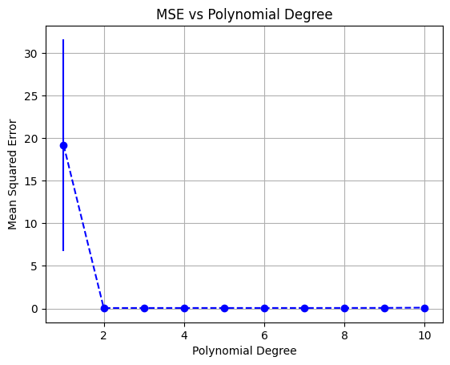

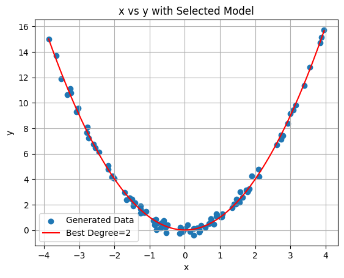

```python
# BEGIN SOLUTION

import numpy as np
import pandas as pd
from sklearn.linear_model import LinearRegression
from sklearn.preprocessing import PolynomialFeatures
from sklearn.model_selection import KFold
import matplotlib.pyplot as plt

# Define constants
N = 100
ORDER = 2
N_FOLDS = 20
POLY_DEGREE = np.arange(1, 11)

# Set random seed for reproducibility
np.random.seed(123)

# Generate simulated data
x = np.random.uniform(low=-4, high=4, size=N)
y = np.random.normal(loc=x**ORDER, scale=0.25, size=N)
data = pd.DataFrame({'x': x, 'y': y})

mean_mse_per_degree = []
std_mse_per_degree = []
mse_dict = dict() # stores each degree as a key and corresponding list of mse_per_fold values as a value

# Perform k-fold cross-validation only once(no replicates)
kf = KFold(n_splits=N_FOLDS, shuffle=True)

# calculate mse_per_fold for each degree and mean and standard deviation of mse estimates for each degree
for degree in POLY_DEGREE:
    mse_deg= []

    for train_index, test_index in kf.split(data):
        x_train, y_train = data.iloc[train_index]['x'], data.iloc[train_index]['y']
        x_test, y_test = data.iloc[test_index]['x'], data.iloc[test_index]['y']

        poly = PolynomialFeatures(degree=degree)
        x_train_poly = poly.fit_transform(x_train.values.reshape(-1, 1))
        x_test_poly = poly.fit_transform(x_test.values.reshape(-1, 1))

        lin_reg = LinearRegression()
        lin_reg.fit(x_train_poly, y_train)
        y_hat = lin_reg.predict(x_test_poly)

        mse_per_fold = np.mean((y_hat - y_test)**2)
        mse_deg.append(mse_per_fold)

    mse_dict[degree] = mse_deg
    mean_mse_per_degree.append(np.mean(mse_deg))
    std_mse_per_degree.append(np.std(mse_deg))

# Plot MSE vs Polynomial Order
plt.errorbar(POLY_DEGREE, mean_mse_per_degree, yerr=std_mse_per_degree, fmt='o--', color='blue')
plt.title('MSE vs Polynomial Degree')
plt.xlabel('Polynomial Degree')
plt.ylabel('Mean Squared Error')
plt.grid(True)
plt.show()

# finds the degree of poly that gives min mse and fit the best degree polynomial
degree_with_min_mse = mean_mse_per_degree.index(min(mean_mse_per_degree)) + 1

best_poly = PolynomialFeatures(degree=degree_with_min_mse)
x_poly = best_poly.fit_transform(data['x'].values.reshape(-1,1))
best_model = LinearRegression()
best_model.fit(x_poly,data['y'])

plt.scatter(data['x'],data['y'],label='Generated Data')
sorted_x = np.linspace(min(x),max(x),100)
y_pred = best_model.predict(best_poly.fit_transform(sorted_x.reshape(-1,1)))
plt.plot(sorted_x,y_pred, color='r', label = f'Best Degree={degree_with_min_mse}')
plt.title('x vs y with Selected Model')
plt.xlabel('x')
plt.ylabel('y')
plt.legend()
plt.grid(True)
plt.show()


# END SOLUTION
```

## Changes done:-

1. No replicates of k-fold cross validation is needed as cross-validation gives us multiple splits of training and validation data. Hence, removed the for loop for replicates thereby reducing the time complexity.
2. Mean and standard deviation of mse estimates for each degree is calculated and mse per fold for each degree is stored in the mse_dict to preserve the information about mse estimate of each fold. The mse_dict contains degrees and corresponding mse per fold values list as key-value pairs.
3. From the MSE vs Polynomial degree plot it is clear that the simplest model with minimum mse is a 2nd degree polynomial model.

## Q4) Bootstrap the following dataset (`n = 1000`) to obtain median and 95% CI (Confidence interval)for parameter estimates (slope and intercept) summarizing the relationship between `x` and `y_measured.` What happens with median parameter estimates when you examine `y` instead?

```python
import numpy as np
from numpy.random import default_rng
import scipy.stats as stats

rng = default_rng(seed=1)
nobs = 1000
x = rng.normal(size=nobs)
y = x - 2 * x**2
y_measured = y + rng.normal(size=nobs)

# BEGIN SOLUTION
from sklearn.utils import resample

def bootstrap_OLS(x,y,bootstrap_samples):
    bootstrap_samples = 1000
    bootstrap_slopes = []
    bootstrap_intercepts = []
    # indices = rng.choice(range(1000),size=1000, replace=True)
    for i in range(bootstrap_samples):

        indices = rng.choice(range(1000),size=1000, replace=True)
        boot_x = x[indices]
        boot_y = y[indices]

        model = stats.linregress(boot_x,boot_y)
        slope = model.slope
        intercept = model.intercept
        bootstrap_intercepts.append(intercept)
        bootstrap_slopes.append(slope)

    return bootstrap_slopes, bootstrap_intercepts

bootstrap_slopes_ymeas, bootstrap_intercepts_ymeas = bootstrap_OLS(x=x,y=y_measured,bootstrap_samples=1000)
slope_median_ymeas = np.median(bootstrap_slopes_ymeas)
intercept_median_ymeas = np.median(bootstrap_intercepts_ymeas)

conf_int_slope_ymeas = (np.percentile(bootstrap_slopes_ymeas,2.5), np.percentile(bootstrap_slopes_ymeas,97.5))
conf_int_intercept_ymeas = (np.percentile(bootstrap_intercepts_ymeas,2.5), np.percentile(bootstrap_intercepts_ymeas,97.5))

print(f'Median of slope while examining y_measured = {slope_median_ymeas}\n')
print(f'Median of intercept while examining y_measured = {intercept_median_ymeas}\n')
print(f'95% Confidence interval of slope while examining y_measured is {conf_int_slope_ymeas}\n')
print(f'95% Confidence interval of intercept while examining y_measured is {conf_int_intercept_ymeas}\n')


bootstrap_slopes_y, bootstrap_intercepts_y = bootstrap_OLS(x=x,y=y,bootstrap_samples=1000)
slope_median_y = np.median(bootstrap_slopes_y)
intercept_median_y = np.median(bootstrap_intercepts_y)

conf_int_slope_y = (np.percentile(bootstrap_slopes_y,2.5), np.percentile(bootstrap_slopes_y,97.5))
conf_int_intercept_y = (np.percentile(bootstrap_intercepts_y,2.5), np.percentile(bootstrap_intercepts_y,97.5))

print(f'\nMedian of slope while examining y = {slope_median_y}\n')
print(f'Median of intercept while examining y = {intercept_median_y}\n')
print(f'95% Confidence interval of slope while examining y is {conf_int_slope_y}\n')
print(f'95% Confidence interval of intercept while examining y is {conf_int_intercept_y}\n')
# END SOLUTION
```

```
Median of slope while examining y_measured = 1.2772615938404126

Median of intercept while examining y_measured = -1.9040056116542856

95% Confidence interval of slope while examining y_measured is (0.7971579334625025, 1.7022244962092756)

95% Confidence interval of intercept while examining y_measured is (-2.093597402653173, -1.7158436396608512)


Median of slope while examining y = 1.2117819298201282

Median of intercept while examining y = -1.9362634679702322

95% Confidence interval of slope while examining y is (0.7715518440365269, 1.622076923155092)

95% Confidence interval of intercept while examining y is (-2.115215561596588, -1.7569873129574205)
```

Provide your answer in this Markdown cell

1. The median of the slope and the median of the intercept decreased when examined with y instead of y_measured.
2. This median of slope and the median of intercept are greater when examined with y_measured because of the normal noise(rng.normal(size=nobs)) present in it.

## Q5) We will predict the number of applications received using the other variables in the **College dataset.** Please load the relevant dataset first.

**Importing Libraries:**

```python
#IMPORT LIBRARIES
import numpy as np
import pandas as pd
from sklearn.linear_model import LinearRegression, RidgeCV, LassoCV
from sklearn.preprocessing import MinMaxScaler, StandardScaler
from sklearn.model_selection import train_test_split, GridSearchCV
from sklearn.metrics import mean_squared_error
```

**Loading dataset:**

```python
#READ data.csv DATASET
org = pd.read_csv('./data.csv')
org.info()
```

```
<class 'pandas.core.frame.DataFrame'>
RangeIndex: 777 entries, 0 to 776
Data columns (total 18 columns):
 #   Column       Non-Null Count  Dtype
---  ------       --------------  -----
 0   private      777 non-null    object
 1   apps         777 non-null    int64
 2   accept       777 non-null    int64
 3   enroll       777 non-null    int64
 4   top10perc    777 non-null    int64
 5   top25perc    777 non-null    int64
 6   f_undergrad  777 non-null    int64
 7   p_undergrad  777 non-null    int64
 8   outstate     777 non-null    int64
 9   room_board   777 non-null    int64
 10  books        777 non-null    int64
 11  personal     777 non-null    int64
 12  phd          777 non-null    int64
 13  terminal     777 non-null    int64
 14  s_f_ratio    777 non-null    float64
 15  perc_alumni  777 non-null    int64
 16  expend       777 non-null    int64
 17  grad_rate    777 non-null    int64
dtypes: float64(1), int64(16), object(1)
memory usage: 109.4+ KB
```

```python
df = org.copy()
df.head()
```

|  | private | apps | accept | enroll | top10perc | top25perc | f_undergrad | p_undergrad | outstate | room_board | books | personal | phd | terminal | s_f_ratio | perc_alumni | expend | grad_rate |
| --- | --- | --- | --- | --- | --- | --- | --- | --- | --- | --- | --- | --- | --- | --- | --- | --- | --- | --- |
| 0 | Yes | 1660 | 1232 | 721 | 23 | 52 | 2885 | 537 | 7440 | 3300 | 450 | 2200 | 70 | 78 | 18.1 | 12 | 7041 | 60 |
| 1 | Yes | 2186 | 1924 | 512 | 16 | 29 | 2683 | 1227 | 12280 | 6450 | 750 | 1500 | 29 | 30 | 12.2 | 16 | 10527 | 56 |
| 2 | Yes | 1428 | 1097 | 336 | 22 | 50 | 1036 | 99 | 11250 | 3750 | 400 | 1165 | 53 | 66 | 12.9 | 30 | 8735 | 54 |
| 3 | Yes | 417 | 349 | 137 | 60 | 89 | 510 | 63 | 12960 | 5450 | 450 | 875 | 92 | 97 | 7.7 | 37 | 19016 | 59 |
| 4 | Yes | 193 | 146 | 55 | 16 | 44 | 249 | 869 | 7560 | 4120 | 800 | 1500 | 76 | 72 | 11.9 | 2 | 10922 | 15 |

```python
#PERFORM PRE PROCESSING OF DATA IF REQUIRED ( OBSERVE THE DATASET AND ITS VALUES CAREFULLY)

# we will encode the 'private' column and normalize the remaining columns
df = org.copy()
df['private'] = df['private'].map({'Yes':1,'No':0})

private_col = df['private']
df = df.drop('private',axis=1)

# #new code
# apps_col = df['apps']
# df = df.drop('apps', axis=1)

scaler = MinMaxScaler()
df_normalized = scaler.fit_transform(df)
df_normalized = pd.DataFrame(df_normalized, columns=df.columns)
df_normalized['private'] = private_col
# df_normalized['apps'] = apps_col
df_normalized
```

|  | apps | accept | enroll | top10perc | top25perc | f_undergrad | p_undergrad | outstate | room_board | books | personal | phd | terminal | s_f_ratio | perc_alumni | expend | grad_rate | private |
| --- | --- | --- | --- | --- | --- | --- | --- | --- | --- | --- | --- | --- | --- | --- | --- | --- | --- | --- |
| 0 | 0.032887 | 0.044177 | 0.107913 | 0.231579 | 0.472527 | 0.087164 | 0.024548 | 0.263430 | 0.239596 | 0.157754 | 0.297710 | 0.652632 | 0.710526 | 0.418231 | 0.187500 | 0.072671 | 0.462963 | 1 |
| 1 | 0.043842 | 0.070531 | 0.075035 | 0.157895 | 0.219780 | 0.080752 | 0.056148 | 0.513430 | 0.736129 | 0.291444 | 0.190840 | 0.221053 | 0.078947 | 0.260054 | 0.250000 | 0.138387 | 0.425926 | 1 |
| 2 | 0.028055 | 0.039036 | 0.047349 | 0.221053 | 0.450549 | 0.028473 | 0.004488 | 0.460227 | 0.310530 | 0.135472 | 0.139695 | 0.473684 | 0.552632 | 0.278820 | 0.468750 | 0.104605 | 0.407407 | 1 |
| 3 | 0.006998 | 0.010549 | 0.016045 | 0.621053 | 0.879121 | 0.011776 | 0.002839 | 0.548554 | 0.578499 | 0.157754 | 0.095420 | 0.884211 | 0.960526 | 0.139410 | 0.578125 | 0.298415 | 0.453704 | 1 |
| 4 | 0.002333 | 0.002818 | 0.003146 | 0.157895 | 0.384615 | 0.003492 | 0.039753 | 0.269628 | 0.368852 | 0.313725 | 0.190840 | 0.715789 | 0.631579 | 0.252011 | 0.031250 | 0.145833 | 0.046296 | 1 |
| ... | ... | ... | ... | ... | ... | ... | ... | ... | ... | ... | ... | ... | ... | ... | ... | ... | ... | ... |
| 772 | 0.044071 | 0.054955 | 0.079912 | 0.031579 | 0.186813 | 0.093639 | 0.092878 | 0.230217 | 0.334174 | 0.180036 | 0.145038 | 0.547368 | 0.473684 | 0.495979 | 0.218750 | 0.024186 | 0.277778 | 0 |
| 773 | 0.039114 | 0.065999 | 0.103823 | 0.242105 | 0.417582 | 0.086021 | 0.050653 | 0.474174 | 0.501261 | 0.224599 | 0.152672 | 0.684211 | 0.671053 | 0.289544 | 0.484375 | 0.113164 | 0.675926 | 1 |
| 774 | 0.041989 | 0.070188 | 0.103823 | 0.347368 | 0.571429 | 0.084243 | 0.007557 | 0.235537 | 0.381463 | 0.232175 | 0.081069 | 0.621053 | 0.671053 | 0.319035 | 0.312500 | 0.096839 | 0.361111 | 1 |
| 775 | 0.221273 | 0.090677 | 0.201667 | 0.989474 | 0.989011 | 0.161186 | 0.003755 | 0.903926 | 0.745586 | 0.237968 | 0.284733 | 0.926316 | 0.947368 | 0.088472 | 0.765625 | 0.701265 | 0.824074 | 1 |
| 776 | 0.060567 | 0.067903 | 0.103193 | 0.284211 | 0.593407 | 0.090433 | 0.079002 | 0.136880 | 0.280580 | 0.180036 | 0.152672 | 0.705263 | 0.671053 | 0.418231 | 0.437500 | 0.024940 | 0.824074 | 1 |

777 rows × 18 columns

### a) Split the data set into a training set and a test set.

```python
# BEGIN SOLUTION
X = df_normalized.drop('apps',axis=1)
y = df_normalized['apps']

X_train, X_test, y_train, y_test = train_test_split(X, y, test_size=0.2, random_state=7)

# END SOLUTION
```

### b) Fit a linear model using least squares on the training set, and report the test error obtained.

Link to linear model: https://scikit-learn.org/stable/modules/generated/sklearn.linear_model.LinearRegression.html

```python
#BEGIN SOLUTION

linreg_model = LinearRegression()
linreg_model.fit(X_train, y_train)

y_predicted = linreg_model.predict(X_test)

test_set_error = mean_squared_error(y_test,y_predicted)
print(f'Test error obtained by fitting linear regression model is {test_set_error}')
# END SOLUTION
```

```
Test error obtained by fitting linear regression model is 0.00038624154928096246
```

### c) Fit a ridge regression model on the training set, with $\lambda$ chosen by cross-validation. Report the test error obtained.

Link to ridge regresion : https://scikit-learn.org/stable/modules/generated/sklearn.linear_model.Ridge.html

```python
#BEGIN SOLUTION

lambdas = np.arange(0.0001, 1000, 100000)
ridge_cv = RidgeCV(alphas=lambdas)

ridge_cv.fit(X_train,y_train)

y_ridge_pred = ridge_cv.predict(X_test)

ridge_test_error = mean_squared_error(y_test,y_ridge_pred)

print(f'Test error obtained by fitting Ridge Regression model is {ridge_test_error}')
# END SOLUTION
```

```
Test error obtained by fitting Ridge Regression model is 0.0003861996846681731
```

### d) Fit a lasso model on the training set, with $\lambda$ chosen by cross-validation. Report the test error obtained, along with the number of non-zero coefficient estimates.

Link to lasso :https://scikit-learn.org/0.15/modules/generated/sklearn.linear_model.Lasso.html

```python
#BEGIN SOLUTION

lambdas = np.arange(0.0001, 1000, 100000)
lasso_cv = LassoCV(alphas=lambdas)

lasso_cv.fit(X_train,y_train)

y_lasso_pred = lasso_cv.predict(X_test)

lasso_test_error = mean_squared_error(y_test,y_lasso_pred)

print(f'Test error obtained by fitting Lasso Regression model is {lasso_test_error}')
print('Number of non-zero coefficient estimates',np.sum(lasso_cv.coef_!=0))
# END SOLUTION
```

```
Test error obtained by fitting Lasso Regression model is 0.0003669473677141466
Number of non-zero coefficient estimates 12
```